# takehomemidterm

**Exam 1 Take Home Portion**

**INSTRUCTIONS**

- This exam is an individual exam.
- This exam is “open-book, open-note, open-Google” but absolutely “no-ChatGPT” or any other AI. You cannot use the code from ChatGPT/AI code generators. ChatGPT/AI code generators output the code in a certain way, and if you use that code, you will be awarded a zero automatically.
- Do not consult with other students.
- Submit your work as a rendered HTML file.
- Late submissions will NOT be accepted without prior approval.
- Be sure that your answers are easy to identify. Do not let the R code and output “speak for you”.
- You may use the “esquisse” package for developing plots (if desired)

Run the lines of code below to read in a dataset containing historical Major League Baseball team performance data.

```r
url = "https://www.dropbox.com/s/9j96ztla5r3bpuy/Teams.csv?raw=1"
teams = read_csv(url)
```

Answer the following questions using the appropriate R code.

**Question 1**

*a)* How many rows and columns are in this dataset?

```r
str(teams)
```

```
spc_tbl_ [2,835 × 48] (S3: spec_tbl_df/tbl_df/tbl/data.frame)
 $ yearID        : num [1:2835] 1871 1871 1871 1871 1871 ...
 $ lgID          : chr [1:2835] NA NA NA NA ...
 $ teamID        : chr [1:2835] "BS1" "CH1" "CL1" "FW1" ...
 $ franchID      : chr [1:2835] "BNA" "CNA" "CFC" "KEK" ...
 $ divID         : chr [1:2835] NA NA NA NA ...
 $ Rank          : num [1:2835] 3 2 8 7 5 1 9 6 4 2 ...
 $ G             : num [1:2835] 31 28 29 19 33 28 25 29 32 58 ...
 $ Ghome         : num [1:2835] NA NA NA NA NA NA NA NA NA NA ...
 $ W             : num [1:2835] 20 19 10 7 16 21 4 13 15 35 ...
 $ L             : num [1:2835] 10 9 19 12 17 7 21 15 15 19 ...
 $ DivWin        : chr [1:2835] NA NA NA NA ...
 $ WCWin         : chr [1:2835] NA NA NA NA ...
 $ LgWin         : chr [1:2835] "N" "N" "N" "N" ...
 $ WSWin         : chr [1:2835] NA NA NA NA ...
 $ R             : num [1:2835] 401 302 249 137 302 376 231 351 310 617 ...
 $ AB            : num [1:2835] 1372 1196 1186 746 1404 ...
 $ H             : num [1:2835] 426 323 328 178 403 410 274 384 375 747 ...
 $ 2B            : num [1:2835] 70 52 35 19 43 66 44 51 54 94 ...
 $ 3B            : num [1:2835] 37 21 40 8 21 27 25 34 26 35 ...
 $ HR            : num [1:2835] 3 10 7 2 1 9 3 6 6 14 ...
 $ BB            : num [1:2835] 60 60 26 33 33 46 38 49 48 27 ...
 $ SO            : num [1:2835] 19 22 25 9 15 23 30 19 13 28 ...
 $ SB            : num [1:2835] 73 69 18 16 46 56 53 62 48 35 ...
 $ CS            : num [1:2835] NA NA NA NA NA NA NA NA NA 15 ...
 $ HBP           : num [1:2835] NA NA NA NA NA NA NA NA NA NA ...
 $ SF            : num [1:2835] NA NA NA NA NA NA NA NA NA NA ...
 $ RA            : num [1:2835] 303 241 341 243 313 266 287 362 303 434 ...
 $ ER            : num [1:2835] 109 77 116 97 121 137 108 153 137 173 ...
 $ ERA           : num [1:2835] 3.55 2.76 4.11 5.17 3.72 4.95 4.3 5.51 4.37 3.02 ...
 $ CG            : num [1:2835] 22 25 23 19 32 27 23 28 32 48 ...
 $ SHO           : num [1:2835] 1 0 0 1 1 0 1 0 0 1 ...
 $ SV            : num [1:2835] 3 1 0 0 0 0 0 0 0 1 ...
 $ IPouts        : num [1:2835] 828 753 762 507 879 ...
 $ HA            : num [1:2835] 367 308 346 261 373 329 315 431 371 566 ...
 $ HRA           : num [1:2835] 2 6 13 5 7 3 3 4 4 3 ...
 $ BBA           : num [1:2835] 42 28 53 21 42 53 34 75 45 63 ...
 $ SOA           : num [1:2835] 23 22 34 17 22 16 16 12 13 0 ...
 $ E             : num [1:2835] 225 218 223 163 227 194 220 198 217 432 ...
 $ DP            : num [1:2835] NA NA NA NA NA NA NA NA NA NA ...
```

[output cut: 46 more lines]

```
  ..   BBA = col_double(),
  ..   SOA = col_double(),
  ..   E = col_double(),
  ..   DP = col_double(),
  ..   FP = col_double(),
  ..   name = col_character(),
  ..   park = col_character(),
  ..   attendance = col_double(),
  ..   BPF = col_double(),
  ..   PPF = col_double(),
  ..   teamIDBR = col_character(),
  ..   teamIDlahman45 = col_character(),
  ..   teamIDretro = col_character()
  .. )
 - attr(*, "problems")=<externalptr>
```

- There are 2835 observations/rows and 48 variables/columns.

*b)* Identify one variable that is categorical.

- teamID is one of the categorical variables.

*c)* Is there missing data? How do you know? If there is missing data, select one variable with missing data and discuss how you might handle the missingness (you do not need to actually write any code).

- Yes, there is missing data and the way I discovered it was through the summary function which shows the amount of missing data for each variables. One of the variables with missing data is Ghome with 399 missing values. In this case I would be hesitant to delete the rows as 399 of 2835 variables is about 14% of my data. So in this case I would try to use imputation through the Mice package.

```r
summary(teams)
```

```
     yearID         lgID              teamID            franchID
 Min.   :1871   Length:2835        Length:2835        Length:2835
 1st Qu.:1920   Class :character   Class :character   Class :character
 Median :1964   Mode  :character   Mode  :character   Mode  :character
 Mean   :1956
 3rd Qu.:1993
 Max.   :2016

    divID                Rank              G             Ghome
 Length:2835        Min.   : 1.000   Min.   :  6.0   Min.   :44.0
 Class :character   1st Qu.: 2.000   1st Qu.:154.0   1st Qu.:77.0
 Mode  :character   Median : 4.000   Median :157.0   Median :81.0
                    Mean   : 4.095   Mean   :150.5   Mean   :78.5
                    3rd Qu.: 6.000   3rd Qu.:162.0   3rd Qu.:81.0
                    Max.   :13.000   Max.   :165.0   Max.   :84.0
                                                     NA's   :399
       W                L             DivWin             WCWin
 Min.   :  0.00   Min.   :  4.00   Length:2835        Length:2835
 1st Qu.: 66.00   1st Qu.: 65.00   Class :character   Class :character
 Median : 77.00   Median : 76.00   Mode  :character   Mode  :character
 Mean   : 74.81   Mean   : 74.81
 3rd Qu.: 87.00   3rd Qu.: 87.00
 Max.   :116.00   Max.   :134.00

    LgWin              WSWin                 R                AB
 Length:2835        Length:2835        Min.   :  24.0   Min.   : 211
 Class :character   Class :character   1st Qu.: 614.0   1st Qu.:5132
 Mode  :character   Mode  :character   Median : 690.0   Median :5395
                                       Mean   : 682.4   Mean   :5146
                                       3rd Qu.: 763.0   3rd Qu.:5518
                                       Max.   :1220.0   Max.   :5781

       H              2B              3B               HR            BB
 Min.   :  33   Min.   :  3.0   Min.   :  0.00   Min.   :  0   Min.   :  0
 1st Qu.:1300   1st Qu.:193.5   1st Qu.: 30.00   1st Qu.: 42   1st Qu.:426
 Median :1393   Median :231.0   Median : 41.00   Median :108   Median :493
 Mean   :1347   Mean   :228.1   Mean   : 46.91   Mean   :102   Mean   :474
 3rd Qu.:1467   3rd Qu.:271.0   3rd Qu.: 60.00   3rd Qu.:150   3rd Qu.:554
 Max.   :1783   Max.   :376.0   Max.   :150.00   Max.   :264   Max.   :835

```

[output cut: 37 more lines]

```
 3rd Qu.:159.0   3rd Qu.:0.9810
 Max.   :217.0   Max.   :0.9910
 NA's   :317
   attendance           BPF             PPF          teamIDBR
 Min.   :   6088   Min.   : 60.0   Min.   : 60.0   Length:2835
 1st Qu.: 534826   1st Qu.: 97.0   1st Qu.: 97.0   Class :character
 Median :1154750   Median :100.0   Median :100.0   Mode  :character
 Mean   :1357173   Mean   :100.2   Mean   :100.2
 3rd Qu.:2042453   3rd Qu.:103.0   3rd Qu.:103.0
 Max.   :4483350   Max.   :129.0   Max.   :141.0
 NA's   :279
 teamIDlahman45     teamIDretro
 Length:2835        Length:2835
 Class :character   Class :character
 Mode  :character   Mode  :character
```

**Question 2**

*a)* Create a new data frame that includes data from the year 1980 to the most recent year in the dataset. **You’ll use this dataset for the remainder the questions regarding baseball**.

```r
baseball = teams %>% filter(yearID >=1980)
summary(baseball)
```

```
     yearID         lgID              teamID            franchID
 Min.   :1980   Length:1048        Length:1048        Length:1048
 1st Qu.:1990   Class :character   Class :character   Class :character
 Median :1999   Mode  :character   Mode  :character   Mode  :character
 Mean   :1999
 3rd Qu.:2008
 Max.   :2016

    divID                Rank             G             Ghome
 Length:1048        Min.   :1.000   Min.   :103.0   Min.   :44.0
 Class :character   1st Qu.:2.000   1st Qu.:162.0   1st Qu.:81.0
 Mode  :character   Median :3.000   Median :162.0   Median :81.0
                    Mean   :3.252   Mean   :158.8   Mean   :79.4
                    3rd Qu.:5.000   3rd Qu.:162.0   3rd Qu.:81.0
                    Max.   :7.000   Max.   :164.0   Max.   :84.0

       W                L             DivWin             WCWin
 Min.   : 37.00   Min.   : 40.00   Length:1048        Length:1048
 1st Qu.: 71.00   1st Qu.: 71.00   Class :character   Class :character
 Median : 80.00   Median : 79.00   Mode  :character   Mode  :character
 Mean   : 79.38   Mean   : 79.38
 3rd Qu.: 89.00   3rd Qu.: 88.00
 Max.   :116.00   Max.   :119.00

    LgWin              WSWin                 R                AB
 Length:1048        Length:1048        Min.   : 329.0   Min.   :3493
 Class :character   Class :character   1st Qu.: 657.0   1st Qu.:5463
 Mode  :character   Mode  :character   Median : 719.5   Median :5522
                                       Mean   : 719.0   Mean   :5430
                                       3rd Qu.: 782.2   3rd Qu.:5583
                                       Max.   :1009.0   Max.   :5781

       H              2B              3B              HR              BB
 Min.   : 797   Min.   :119.0   Min.   : 6.00   Min.   : 32.0   Min.   :275.0
 1st Qu.:1373   1st Qu.:247.0   1st Qu.:25.00   1st Qu.:125.0   1st Qu.:470.8
 Median :1433   Median :272.0   Median :31.00   Median :152.0   Median :519.0
 Mean   :1420   Mean   :269.1   Mean   :31.63   Mean   :152.6   Mean   :520.1
 3rd Qu.:1494   3rd Qu.:294.0   3rd Qu.:37.00   3rd Qu.:178.0   3rd Qu.:571.0
 Max.   :1684   Max.   :376.0   Max.   :68.00   Max.   :264.0   Max.   :775.0

```

[output cut: 37 more lines]

```
 3rd Qu.:161   3rd Qu.:0.9840
 Max.   :206   Max.   :0.9910

   attendance           BPF             PPF          teamIDBR
 Min.   : 469090   Min.   : 88.0   Min.   : 88.0   Length:1048
 1st Qu.:1668159   1st Qu.: 97.0   1st Qu.: 97.0   Class :character
 Median :2147773   Median :100.0   Median :100.0   Mode  :character
 Mean   :2206312   Mean   :100.2   Mean   :100.2
 3rd Qu.:2725763   3rd Qu.:103.0   3rd Qu.:103.0
 Max.   :4483350   Max.   :129.0   Max.   :129.0

 teamIDlahman45     teamIDretro
 Length:1048        Length:1048
 Class :character   Class :character
 Mode  :character   Mode  :character
```

*b)* How many rows are in your new data frame?

- There are 1048 rows and 48 variables in the baseball data frame.

*c)* Create a new variable called “RD” (for run differential) that is equal to R-RA.

```r
baseball = baseball %>% mutate(RD = R-RA)
```

*d)* Create a new variable called “Wpct” that is equal to 100*W/(W+L).

```r
baseball = baseball %>% mutate(Wpct = 100*W/(W+L))
```

*e)* What are the minimum and maximum values for Wpct in the new data frame?

- The min is 26.54 and the max is 71.60

```r
summary(baseball)
```

```
     yearID         lgID              teamID            franchID
 Min.   :1980   Length:1048        Length:1048        Length:1048
 1st Qu.:1990   Class :character   Class :character   Class :character
 Median :1999   Mode  :character   Mode  :character   Mode  :character
 Mean   :1999
 3rd Qu.:2008
 Max.   :2016

    divID                Rank             G             Ghome
 Length:1048        Min.   :1.000   Min.   :103.0   Min.   :44.0
 Class :character   1st Qu.:2.000   1st Qu.:162.0   1st Qu.:81.0
 Mode  :character   Median :3.000   Median :162.0   Median :81.0
                    Mean   :3.252   Mean   :158.8   Mean   :79.4
                    3rd Qu.:5.000   3rd Qu.:162.0   3rd Qu.:81.0
                    Max.   :7.000   Max.   :164.0   Max.   :84.0

       W                L             DivWin             WCWin
 Min.   : 37.00   Min.   : 40.00   Length:1048        Length:1048
 1st Qu.: 71.00   1st Qu.: 71.00   Class :character   Class :character
 Median : 80.00   Median : 79.00   Mode  :character   Mode  :character
 Mean   : 79.38   Mean   : 79.38
 3rd Qu.: 89.00   3rd Qu.: 88.00
 Max.   :116.00   Max.   :119.00

    LgWin              WSWin                 R                AB
 Length:1048        Length:1048        Min.   : 329.0   Min.   :3493
 Class :character   Class :character   1st Qu.: 657.0   1st Qu.:5463
 Mode  :character   Mode  :character   Median : 719.5   Median :5522
                                       Mean   : 719.0   Mean   :5430
                                       3rd Qu.: 782.2   3rd Qu.:5583
                                       Max.   :1009.0   Max.   :5781

       H              2B              3B              HR              BB
 Min.   : 797   Min.   :119.0   Min.   : 6.00   Min.   : 32.0   Min.   :275.0
 1st Qu.:1373   1st Qu.:247.0   1st Qu.:25.00   1st Qu.:125.0   1st Qu.:470.8
 Median :1433   Median :272.0   Median :31.00   Median :152.0   Median :519.0
 Mean   :1420   Mean   :269.1   Mean   :31.63   Mean   :152.6   Mean   :520.1
 3rd Qu.:1494   3rd Qu.:294.0   3rd Qu.:37.00   3rd Qu.:178.0   3rd Qu.:571.0
 Max.   :1684   Max.   :376.0   Max.   :68.00   Max.   :264.0   Max.   :775.0

```

[output cut: 40 more lines]

```
   attendance           BPF             PPF          teamIDBR
 Min.   : 469090   Min.   : 88.0   Min.   : 88.0   Length:1048
 1st Qu.:1668159   1st Qu.: 97.0   1st Qu.: 97.0   Class :character
 Median :2147773   Median :100.0   Median :100.0   Mode  :character
 Mean   :2206312   Mean   :100.2   Mean   :100.2
 3rd Qu.:2725763   3rd Qu.:103.0   3rd Qu.:103.0
 Max.   :4483350   Max.   :129.0   Max.   :129.0

 teamIDlahman45     teamIDretro              RD            Wpct
 Length:1048        Length:1048        Min.   :-337   Min.   :26.54
 Class :character   Class :character   1st Qu.: -70   1st Qu.:45.06
 Mode  :character   Mode  :character   Median :   1   Median :50.00
                                       Mean   :   0   Mean   :50.00
                                       3rd Qu.:  71   3rd Qu.:54.94
                                       Max.   : 309   Max.   :71.60
```

**Question 3**

Develop an appropriate plot to examine the relationship between run differential (RD) and win percentage (Wpct). Which variable should be used to predict the other? Does this plot support your intuition regarding the relationship between these two variables?

- I used a scatter plot to compare the two numerical variables and I chose to put Wpct as the Y and RD as the X because we are trying to figure out the chance of a team winning based on the variable RD. Yes, this plot does support my intuition regarding the relationship because as RD increases I would expect the chance of winning to increase and vice verse.

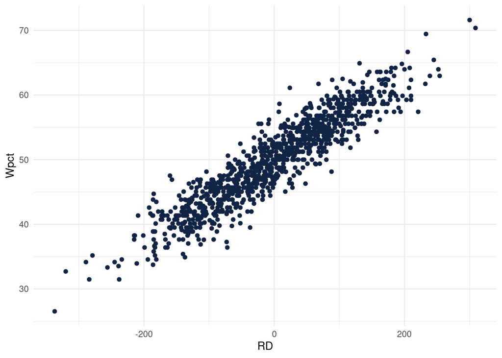

```r
#esquisser()

library(ggplot2)

ggplot(baseball) +
 aes(x = RD, y = Wpct) +
 geom_point(colour = "#112446") +
 theme_minimal()
```

**Question 4**

Use the non-Tidymodels syntax to build a linear regression model to predict “Wpct” with “RD”. Comment on the quality of the resulting model. Include a brief examination of residuals in your commentary on model quality.

- This is overall a pretty good model as the R-squared value is hovering around 86% which means the model has a pretty good fit when comparing the predictions to the actual data points. The p-value is also way below the limit of 0.05 so we know RD is significant. From a residual point of view from the strong min and max values but a miniscule median I can tell that the data has some definite outliers but overall the errors are centered around 0.

```r
model1 = lm(Wpct ~ RD, baseball)
summary(model1)
```

```
Call:
lm(formula = Wpct ~ RD, data = baseball)

Residuals:
    Min      1Q  Median      3Q     Max
-8.9621 -1.7191  0.0593  1.7714  9.5743

Coefficients:
             Estimate Std. Error t value Pr(>|t|)
(Intercept) 5.000e+01  7.916e-02  631.60   <2e-16 ***
RD          6.411e-02  8.024e-04   79.91   <2e-16 ***
---
Signif. codes:  0 '***' 0.001 '**' 0.01 '*' 0.05 '.' 0.1 ' ' 1

Residual standard error: 2.563 on 1046 degrees of freedom
Multiple R-squared:  0.8592,    Adjusted R-squared:  0.8591
F-statistic:  6385 on 1 and 1046 DF,  p-value: < 2.2e-16
```

**Question 5**

Repeat Question 4 using the Tidymodels syntax.

```r
baseball_recipe = recipe(Wpct ~ RD, data = baseball) %>% step_dummy(all_nominal())

lm_model = linear_reg()%>% set_engine("lm")

lm_workflow = workflow() %>% add_model(lm_model) %>% add_recipe(baseball_recipe)

lm_fit = fit(lm_workflow, baseball)
```

```r
glance(lm_fit)
```

```
# A tibble: 1 × 12
  r.squared adj.r.squared sigma statistic p.value    df logLik   AIC   BIC
      <dbl>         <dbl> <dbl>     <dbl>   <dbl> <dbl>  <dbl> <dbl> <dbl>
1     0.859         0.859  2.56     6385.       0     1 -2472. 4951. 4965.
# ℹ 3 more variables: deviance <dbl>, df.residual <int>, nobs <int>
```

```r
tidy(lm_fit)
```

```
# A tibble: 2 × 5
  term        estimate std.error statistic p.value
  <chr>          <dbl>     <dbl>     <dbl>   <dbl>
1 (Intercept)  50.0     0.0792       632.        0
2 RD            0.0641  0.000802      79.9       0
```

```r
baseball = baseball %>% augment(lm_fit,.)
summary(baseball)
```

```
     .pred           .resid             yearID         lgID
 Min.   :28.39   Min.   :-8.96208   Min.   :1980   Length:1048
 1st Qu.:45.51   1st Qu.:-1.71910   1st Qu.:1990   Class :character
 Median :50.06   Median : 0.05933   Median :1999   Mode  :character
 Mean   :50.00   Mean   : 0.00000   Mean   :1999
 3rd Qu.:54.55   3rd Qu.: 1.77144   3rd Qu.:2008
 Max.   :69.81   Max.   : 9.57431   Max.   :2016

    teamID            franchID            divID                Rank
 Length:1048        Length:1048        Length:1048        Min.   :1.000
 Class :character   Class :character   Class :character   1st Qu.:2.000
 Mode  :character   Mode  :character   Mode  :character   Median :3.000
                                                          Mean   :3.252
                                                          3rd Qu.:5.000
                                                          Max.   :7.000

       G             Ghome            W                L
 Min.   :103.0   Min.   :44.0   Min.   : 37.00   Min.   : 40.00
 1st Qu.:162.0   1st Qu.:81.0   1st Qu.: 71.00   1st Qu.: 71.00
 Median :162.0   Median :81.0   Median : 80.00   Median : 79.00
 Mean   :158.8   Mean   :79.4   Mean   : 79.38   Mean   : 79.38
 3rd Qu.:162.0   3rd Qu.:81.0   3rd Qu.: 89.00   3rd Qu.: 88.00
 Max.   :164.0   Max.   :84.0   Max.   :116.00   Max.   :119.00

    DivWin             WCWin              LgWin              WSWin
 Length:1048        Length:1048        Length:1048        Length:1048
 Class :character   Class :character   Class :character   Class :character
 Mode  :character   Mode  :character   Mode  :character   Mode  :character




       R                AB             H              2B              3B
 Min.   : 329.0   Min.   :3493   Min.   : 797   Min.   :119.0   Min.   : 6.00
 1st Qu.: 657.0   1st Qu.:5463   1st Qu.:1373   1st Qu.:247.0   1st Qu.:25.00
 Median : 719.5   Median :5522   Median :1433   Median :272.0   Median :31.00
 Mean   : 719.0   Mean   :5430   Mean   :1420   Mean   :269.1   Mean   :31.63
 3rd Qu.: 782.2   3rd Qu.:5583   3rd Qu.:1494   3rd Qu.:294.0   3rd Qu.:37.00
 Max.   :1009.0   Max.   :5781   Max.   :1684   Max.   :376.0   Max.   :68.00

```

[output cut: 48 more lines]

```
      PPF          teamIDBR         teamIDlahman45     teamIDretro
 Min.   : 88.0   Length:1048        Length:1048        Length:1048
 1st Qu.: 97.0   Class :character   Class :character   Class :character
 Median :100.0   Mode  :character   Mode  :character   Mode  :character
 Mean   :100.2
 3rd Qu.:103.0
 Max.   :129.0

       RD            Wpct
 Min.   :-337   Min.   :26.54
 1st Qu.: -70   1st Qu.:45.06
 Median :   1   Median :50.00
 Mean   :   0   Mean   :50.00
 3rd Qu.:  71   3rd Qu.:54.94
 Max.   : 309   Max.   :71.60
```

```r
final_mod = lm_fit %>% extract_fit_parsnip()
final_mod
```

```
parsnip model object


Call:
stats::lm(formula = ..y ~ ., data = data)

Coefficients:
(Intercept)           RD
   49.99806      0.06411
```

- From the model the P-value is displayed as 0 which means the value was so small it could not even be displayed therefore, the variable is very significant. From the glance function I can still see that the R-squared value is about 85% which is very significant. Overall this is a pretty good model to use.

**Question 6**

For a team with a run differential of 500, what would that team’s predicted win percentage be? Comment on the appropriateness of using your model to make this prediction.

- If a team has an RD of 500 according to my model they would have an 82.05% chance of winning. I would say this model is pretty appropriate though i would like to add some more variables if possible. While just the RD has an 86% R-squared it could be theoretically higher. In the end though, with just RD I would trust this outcome.

```r
b = 49.99806 + 0.06411*500
print(b)
```

```
[1] 82.05306
```

Before proceeding to the next question, read-in the “cereal.csv” file into a data frame called “cereal”. A brief description of the variables in this dataset is provided below:

```r
cereal = read_csv("cereal.csv")
```

- name: Name of cereal
- rating: a rating of the cereals
- calories: calories per serving
- protein: grams of protein
- fat: grams of fat
- sodium: milligrams of sodium
- fiber: grams of dietary fiber
- carbo: grams of complex carbohydrates
- sugars: grams of sugars
- potass: milligrams of potassium
- vitamins: vitamins and minerals, typical percentage of FDA recommended

**Question 7**

Delete the “name” variable.

```r
cereal = cereal %>% select(-name)
```

```r
set.seed(1234)
cereal_split = initial_split(cereal, prop = 0.6, strata = rating)
train = training(cereal_split)
test = testing(cereal_split)
str(train)
```

```
tibble [45 × 10] (S3: tbl_df/tbl/data.frame)
 $ rating  : num [1:45] 34.4 33.2 18 19.8 22.7 22.4 36.2 31.4 35.3 23.8 ...
 $ calories: num [1:45] 110 110 120 120 110 110 100 110 100 110 ...
 $ protein : num [1:45] 2 2 1 1 1 1 2 1 2 1 ...
 $ fat     : num [1:45] 2 0 2 3 1 1 1 0 0 1 ...
 $ sodium  : num [1:45] 200 125 220 210 180 180 140 200 45 280 ...
 $ fiber   : num [1:45] 1 1 0 0 0 0 2 1 0 0 ...
 $ carbo   : num [1:45] 14 11 12 13 12 12 11 14 11 15 ...
 $ sugars  : num [1:45] 8 14 12 9 13 13 10 11 15 9 ...
 $ potass  : num [1:45] 155 30 35 45 55 65 120 25 40 45 ...
 $ vitamins: num [1:45] 25 25 25 25 25 25 25 25 25 25 ...
```

```r
str(test)
```

```
tibble [32 × 10] (S3: tbl_df/tbl/data.frame)
 $ rating  : num [1:32] 68.4 34 29.5 37 50.8 35.8 64.5 44.3 32.2 40.9 ...
 $ calories: num [1:32] 70 120 110 130 110 110 100 100 110 120 ...
 $ protein : num [1:32] 4 3 2 3 6 1 3 2 2 3 ...
 $ fat     : num [1:32] 1 5 2 2 2 0 0 0 1 2 ...
 $ sodium  : num [1:32] 130 15 180 210 290 90 80 190 125 160 ...
 $ fiber   : num [1:32] 10 2 1.5 2 2 1 1 1 1 5 ...
 $ carbo   : num [1:32] 5 8 10.5 18 17 13 21 18 11 12 ...
 $ sugars  : num [1:32] 6 8 10 8 1 12 0 5 13 10 ...
 $ potass  : num [1:32] 280 135 70 100 105 20 45 80 30 200 ...
 $ vitamins: num [1:32] 25 0 25 25 25 25 0 25 25 25 ...
```

This is a relatively small dataset, so apply a 60/40 training/test split (60% to training, 40% to testing). The response variable is “rating”.

**Question 8**

Create appropriate visualizations (using the training set) to examine the relationships between each variable (except “name”) and the response variable “rating”.

```r
cereal1 = cereal %>% select(- rating)
```

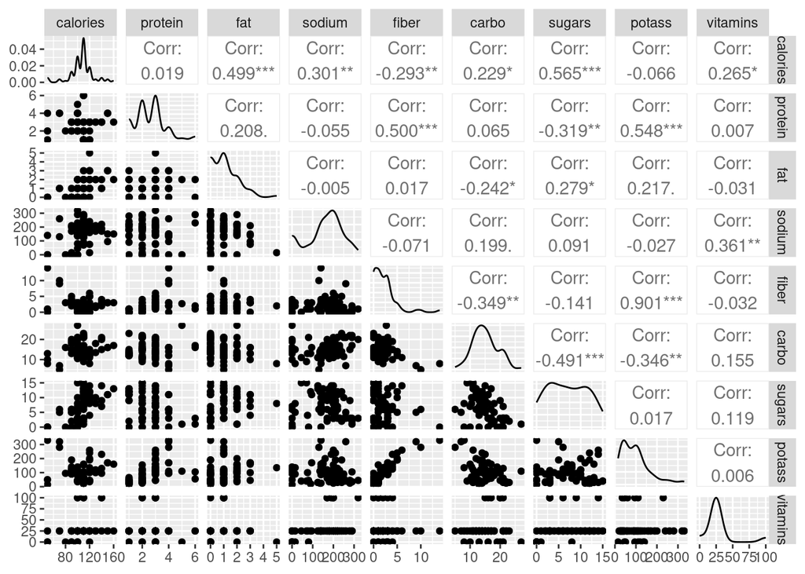

```r
ggpairs(cereal1)
```

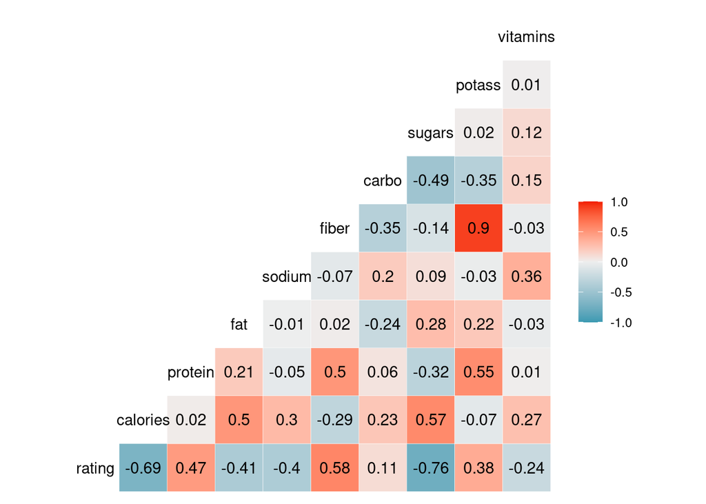

```r
ggcorr(cereal, label = TRUE, label_round = 2)
```

**Question 9**

Build the best linear regression model (on the training set) that you can. If you build multiple models, you only need to keep your best model in your final document.

```r
train_recipe7 =
  recipe(rating ~ sugars + calories + protein + sodium + fat + fiber , data = train)

lm_model7 =
  linear_reg() %>%
  set_engine("lm")

lm_wflow7 =
  workflow() %>%
  add_model(lm_model7) %>%
  add_recipe(train_recipe7)

lm_fit7 = fit(lm_wflow7, train)

tidy(lm_fit7)
```

```
# A tibble: 7 × 5
  term        estimate std.error statistic  p.value
  <chr>          <dbl>     <dbl>     <dbl>    <dbl>
1 (Intercept)  58.6      1.96       29.9   4.96e-28
2 sugars       -1.66     0.0725    -22.9   7.73e-24
3 calories     -0.0223   0.0227     -0.983 3.32e- 1
4 protein       2.20     0.372       5.91  7.47e- 7
5 sodium       -0.0540   0.00324   -16.7   4.53e-19
6 fat          -3.91     0.300     -13.0   1.30e-15
7 fiber         2.42     0.139      17.4   1.11e-19
```

```r
glance(lm_fit7)
```

```
# A tibble: 1 × 12
  r.squared adj.r.squared sigma statistic  p.value    df logLik   AIC   BIC
      <dbl>         <dbl> <dbl>     <dbl>    <dbl> <dbl>  <dbl> <dbl> <dbl>
1     0.992         0.990  1.50      745. 8.08e-38     6  -78.4  173.  187.
# ℹ 3 more variables: deviance <dbl>, df.residual <int>, nobs <int>
```

```r
lm_last = last_fit(lm_wflow7, split = cereal_split)
```

```r
options(scipen=999)
collect_metrics(lm_last)
```

```
# A tibble: 2 × 4
  .metric .estimator .estimate .config
  <chr>   <chr>          <dbl> <chr>
1 rmse    standard       3.07  Preprocessor1_Model1
2 rsq     standard       0.940 Preprocessor1_Model1
```

```r
options(scipen=0)
```

**Question 10**

Comment on the quality of your model that you created in **Question 9**.

**End of Exam**